# Dissolved Oxygen Recovery Project

Statistic summary

```r
summary(lm2)
```

```
Call:
lm(formula = H11043_winkelec[, 1] ~ H11043_winkelec[, 2])

Residuals:
     Min       1Q   Median       3Q      Max
-0.77188 -0.15051  0.04768  0.19181  0.49000

Coefficients:
                     Estimate Std. Error t value Pr(>|t|)
(Intercept)            2.8913     0.6757   4.279 0.000159 ***
H11043_winkelec[, 2]   0.5370     0.1240   4.332 0.000136 ***
---
Signif. codes:  0 ‘***’ 0.001 ‘**’ 0.01 ‘*’ 0.05 ‘.’ 0.1 ‘ ’ 1

Residual standard error: 0.2698 on 32 degrees of freedom
  (276 observations deleted due to missingness)
Multiple R-squared:  0.3697,    Adjusted R-squared:   0.35
F-statistic: 18.77 on 1 and 32 DF,  p-value: 0.0001365
```

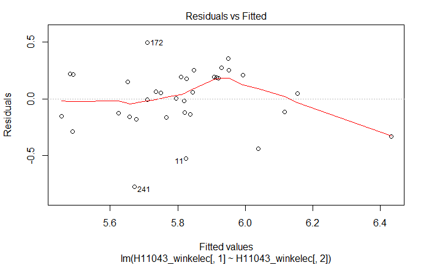

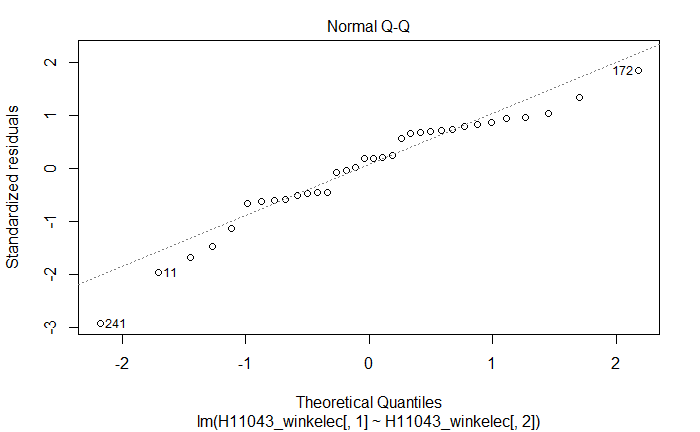

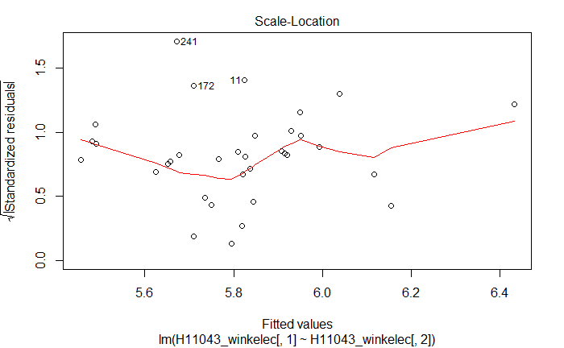

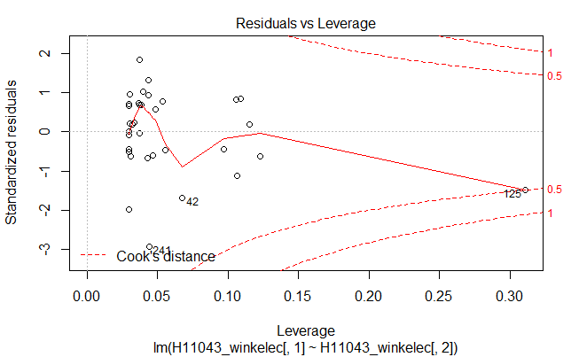

```r
plot(lm2)
```

For cruise HUD2012042

```r
length(H12042_elec_data) <- 486
H12042_winkelec <- matrix(NA, nrow = 486, ncol = 2)
for( i in 1:486){
  if(!is.null(match3[[i]])){
    H12042_winkelec[i,1] <- H12042_wink_data[[i]]
    H12042_winkelec[i,2] <- H12042_elec_data[[match3[[i]]]]
   # }else{
   #   H12042_winkelec[i,] <- NULL
   }
}
plot(H12042_winkelec[,1], H12042_winkelec[,2],xlim = c(0,7), ylim = c(0,7), xlab = 'Winkler Data', ylab = 'Electrode Data')
par(new = TRUE)
```

```r
lm3 <- lm(H12042_winkelec[,1] ~ H12042_winkelec[,2])
abline(lm3)
abline(coef = c(0, 1), col = 'red')
```

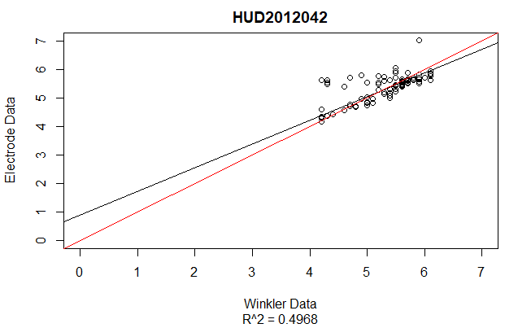

```r
title(main = 'HUD2012042')
title(sub = 'R^2 = 0.4968')
```

Where black line represents simple linear regression on the data and red line represents perfect 1:1 relationship with 0 intercept.

Statistic summary

```r
summary(lm3)
```

```
Call:
lm(formula = H12042_winkelec[, 1] ~ H12042_winkelec[, 2])

Residuals:
    Min      1Q  Median      3Q     Max
-1.3420 -0.1528  0.1133  0.2371  0.5601

Coefficients:
                     Estimate Std. Error t value Pr(>|t|)
(Intercept)           0.89119    0.46932   1.899   0.0607 .
H12042_winkelec[, 2]  0.82843    0.08693   9.530 2.22e-15 ***
---
Signif. codes:  0 ‘***’ 0.001 ‘**’ 0.01 ‘*’ 0.05 ‘.’ 0.1 ‘ ’ 1

Residual standard error: 0.3978 on 92 degrees of freedom
  (392 observations deleted due to missingness)
Multiple R-squared:  0.4968,    Adjusted R-squared:  0.4913
F-statistic: 90.83 on 1 and 92 DF,  p-value: 2.221e-15
```

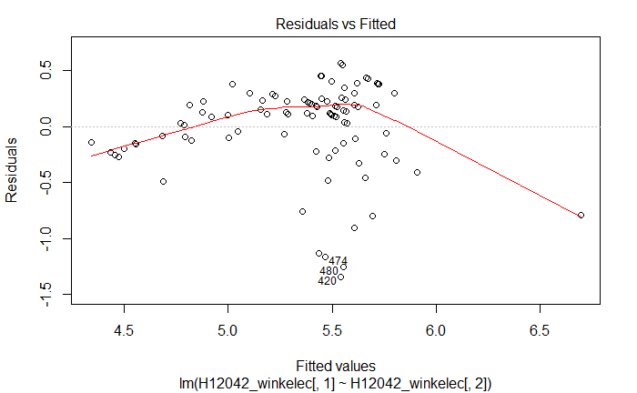

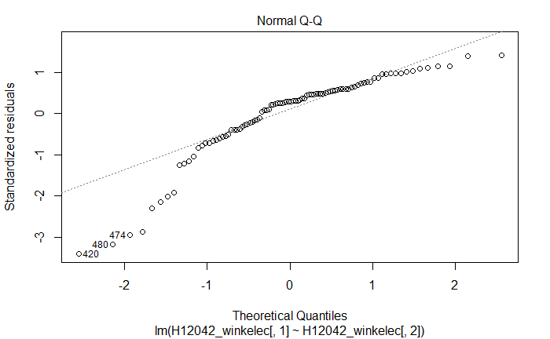

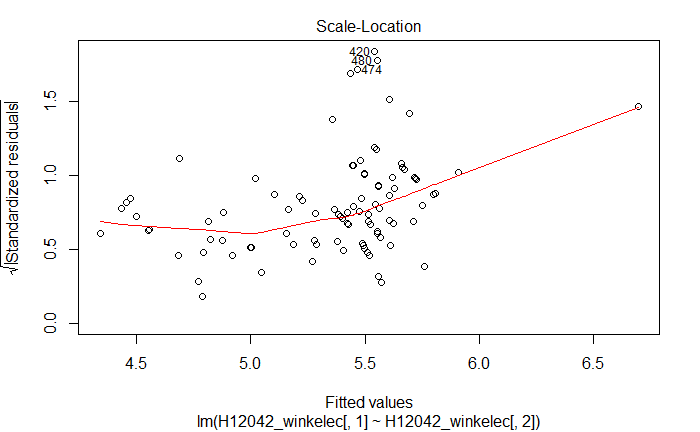

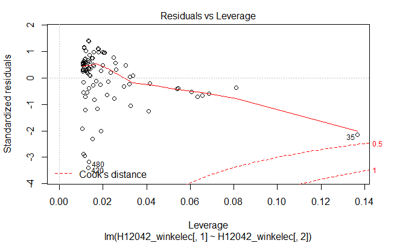

```r
plot(lm3)
```

In order to determine if the relationship between Winkler and electrode data was pressure dependent the differences by cruise were plotted over depth along with simple linear regression and summary statistics

For HUD2011004

```r
length(H11004_wink_dpth) <- 131
plot( H11004_wink_dpth, unlist(H11004_wink_elec_1), ylim = c(-2, 2), xlab = 'Depth (m)', ylab = 'Difference (Winkler - electrode)')
abline(h = 0, col = 'blue')
```

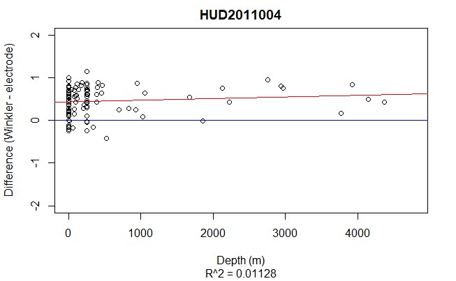

```r
ll <- lm( unlist(H11004_wink_elec_1) ~ H11004_wink_dpth)
abline(ll, col = 'red')
title(main = 'HUD2011004', sub = 'R^2 = 0.01128')
```

```r
summary(ll)
```

```
Call:
lm(formula = unlist(H11004_wink_elec_1) ~ H11004_wink_dpth)

Residuals:
     Min       1Q   Median       3Q      Max
-0.88809 -0.21947  0.09733  0.25251  0.70152

Coefficients:
                  Estimate Std. Error t value Pr(>|t|)
(Intercept)      4.405e-01  3.675e-02  11.988   <2e-16 ***
H11004_wink_dpth 3.770e-05  3.494e-05   1.079    0.283
---
Signif. codes:  0 ‘***’ 0.001 ‘**’ 0.01 ‘*’ 0.05 ‘.’ 0.1 ‘ ’ 1

Residual standard error: 0.3342 on 102 degrees of freedom
  (27 observations deleted due to missingness)
Multiple R-squared:  0.01128,   Adjusted R-squared:  0.00159
F-statistic: 1.164 on 1 and 102 DF,  p-value: 0.2832
```

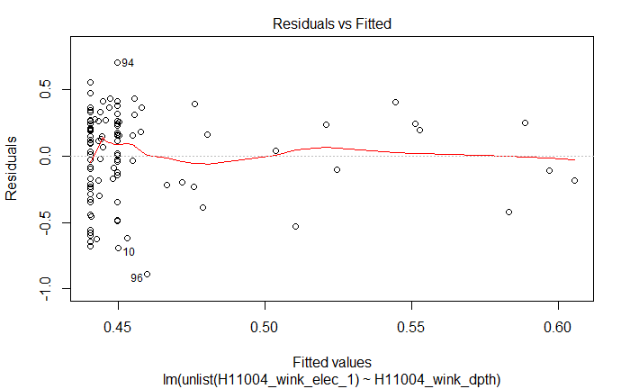

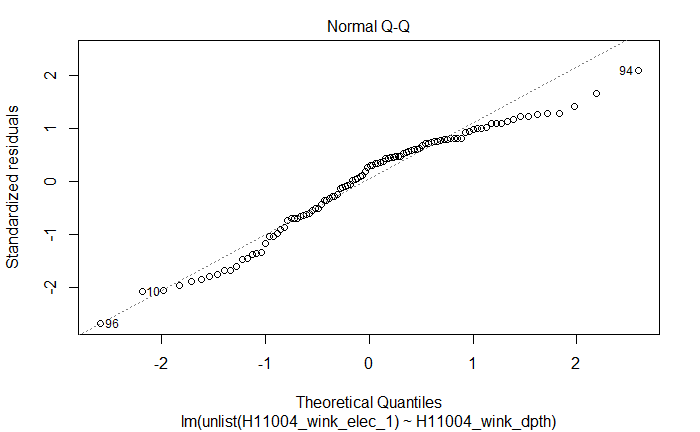

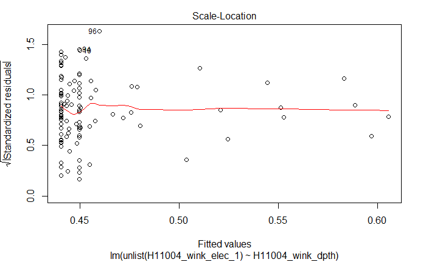

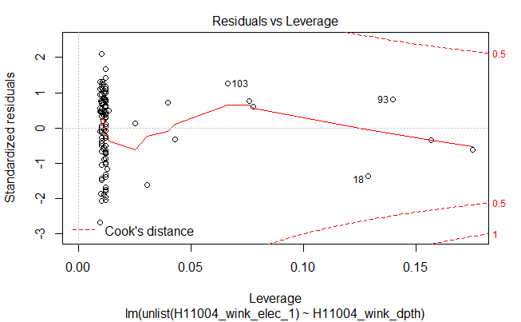

```r
plot(ll)
```

For HUD2011043

```r
dp2 <- list()
for (i in 1:length(H11043_wink_elec_1)){
  if(is.null(H11043_wink_elec_1[[i]])){
    dp2[i] <- NULL
  } else{
    dp2[i] <- H11043_wink_dpth[[i]]
  }
}
plot(unlist(dp2), unlist(H11043_wink_elec_1), ylim = c(-2, 2), xlab = 'Depth (m)', ylab = 'Difference (Winkler - Electrode)')
abline(h = 0, col = 'blue')
```

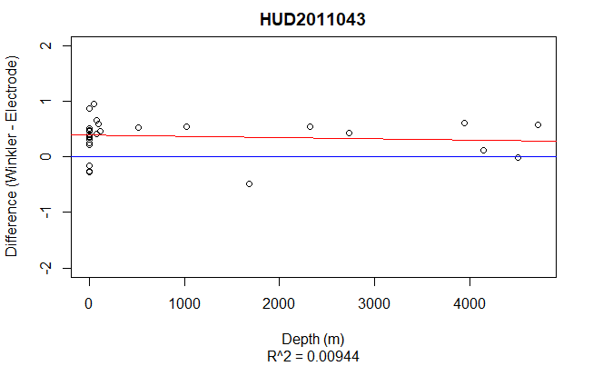

```r
ll2 <- lm(unlist(H11043_wink_elec_1) ~ unlist(dp2))
abline(ll2, col = 'red')
title(main = 'HUD2011043', sub = 'R^2 = 0.00944')
```

```r
summary(ll2)
```

```
Call:
lm(formula = unlist(H11043_wink_elec_1) ~ unlist(dp2))

Residuals:
     Min       1Q   Median       3Q      Max
-0.84757 -0.12671  0.06725  0.16245  0.56277

Coefficients:
              Estimate Std. Error t value Pr(>|t|)
(Intercept)  3.893e-01  6.233e-02   6.245 5.35e-07 ***
unlist(dp2) -2.088e-05  3.780e-05  -0.552    0.585
---
Signif. codes:  0 ‘***’ 0.001 ‘**’ 0.01 ‘*’ 0.05 ‘.’ 0.1 ‘ ’ 1

Residual standard error: 0.3218 on 32 degrees of freedom
  (22 observations deleted due to missingness)
Multiple R-squared:  0.009444,  Adjusted R-squared:  -0.02151
F-statistic: 0.3051 on 1 and 32 DF,  p-value: 0.5845
```